# Lab 02

w271

Alex Yang, John Kenney, Ram Balasubramanian

Oct 12, 2017

# SECTION - 1 INTRODUCTION & KEY RESULTS

## Problem Introduction:

We have been hired by a Private University to identify who among their Alumni are most likely to contribute towards the University’s foundation in future years. The university has provided us with data on past contributions from graduates - data includes some demogracramerc information (like gender, marital status), university specific information (graduation year, major of studies), and some information on how “connected”" an Alumnus is to the school (Alumni event attendance, historical contributions).

## 1.1 HIGH LEVEL DESCRIPTION OF MODELING APPROACH:

We have taken two approaches to the problem (named Beta-Hat and Y-Hat):  
Approach “Beta-Hat”: We will treat the problem as a “explanation” problem ($\hat{\beta}$). The goal here is to figure out if and how much certain aspects of a person and their association with the university determines how much they will contribute to the university’s foundation. We will develop a regression model that considers the 2016 contributions as a variable that depends on one or more of the other data elements that have been provided. The regression coefficients can then be interpreted as a measure of how much each aspect of a person influences their contributions.

Approach “Y-Hat”:  
We will treat the problem as a “prediction” problem ($\hat{y}$ problem). Given all the data we have about a person and their past contributions, can we predict how much they will contribute in the future. We will develop a model that aims to predict the 2016 contribution amounts for each person. To evaluate the efficacy of our models, we will split the data into a “training” set and a “test” set. We will use the training data to estimate parameters for our prediction model and evaluate our model’s prediction accuracy using the test set.

# SECTION 2 - DATA EXAMINATION AND EDA:

```r
library(knitr)
opts_chunk$set(tidy.opts=list(width.cutoff=60),tidy=TRUE)

#Libraries required
library(car)
library(dplyr)
library(Hmisc)#Used by author for 3D plotting
library(ggplot2)
library(gridExtra)
library(effsize) #Used to calculate Cohen's D for T-Test
library(aod)    #Used for effect size of the logit model
library(mcprofile) #Used for confidence intervals
library(package = MASS)  # Location of parcoord() function
library(vcd)
library(data.table)
library(stargazer)
library(caret) #Required for Confusion Matrix
library(ordinal)
```

```r
dt <- fread("lab2data.csv")
describe(dt)
```

```
## dt
##
##  12  Variables      1000  Observations
## ---------------------------------------------------------------------------
## V1
##        n  missing distinct
##     1000        0     1000
##
## lowest : 1    10   100  1002 1003, highest: 995  996  997  998  999
## ---------------------------------------------------------------------------
## Gender
##        n  missing distinct
##     1000        0        2
##
## Value          F     M
## Frequency    505   495
## Proportion 0.505 0.495
## ---------------------------------------------------------------------------
## Class.Year
##        n  missing distinct     Info     Mean      Gmd
##     1000        0        5    0.949     1996    15.07
##
## Value       1972  1982  1992  2002  2012
## Frequency    105   176   203   223   293
## Proportion 0.105 0.176 0.203 0.223 0.293
## ---------------------------------------------------------------------------
## Marital.Status
##        n  missing distinct
##     1000        0        4
##
## Value          D     M     S     W
## Frequency     61   584   344    11
## Proportion 0.061 0.584 0.344 0.011
## ---------------------------------------------------------------------------
## Major
##        n  missing distinct
##     1000        0       45
##
## lowest : American Studies     Anthropology         Art                  Biology              Chemistry
## highest: Spanish              Speech (Drama, etc.) Speech Correction    Theatre              Zoology
```

[output cut: 47 more lines]

```
##      .25      .50      .75      .90      .95
##      0.0      0.0     75.0    200.0    538.3
##
## lowest :     0.0     5.0    10.0    13.0    15.0
## highest: 10000.0 14776.0 15634.5 26500.0 58785.5
## ---------------------------------------------------------------------------
## FY16Giving
##        n  missing distinct     Info     Mean      Gmd      .05      .10
##     1000        0       71    0.798      170    308.2        0        0
##      .25      .50      .75      .90      .95
##        0        0       75      216      500
##
## lowest :     0.00     5.00    10.00    15.00    18.00
## highest:  5000.00  6500.00 11500.00 11505.84 14655.25
## ---------------------------------------------------------------------------
```

## 2.1 Brief Description of Data Available:

We have data for 1000 past graduates of the University. There are 12 variables provided for each Alumnus. They are: 1. V1: Identifier for each record (Alumnus)  
2. Gender: M/F, roughly 50/50 in the sample provided. 3. Class.Year: Appears like the “decade” of the graduating year. Goes from 1972 - 2012. We will assume 1972 represents students graduating from 1963-1972; 1982 represents students graduating from 1973 to 1982 etc.  
4. Marital.Status: Has 4 categories - coded D,M,S,W. We will assume it means Divorced, Married, Single, Widowed with over 90% in the “married” or “single” categories.  
5. Major: There are 45 majors represented in the sample. History, English, Biology & Economics are the top 4 representing about 37% of the sample.  
6. Next.Degree: We assume this means what the alumnus went on to do after graduating from the university. 38% shows “None” implying they did not pursue another degree. The remainder (62%) seems rather high for this metric.  
7. AttendenceEvent: Indicates whether the alumnus attended an alumni event between 2012 and 2015. If we choose to use this variable to model “Giving” we should probably not use it to model 2012-2014 Giving  
8. FYGiving: There are 5 of these variables named FY12 - FY16 representing full year 2012 through full year 2016 contribution from the alumnus. There are some “outliers” (e.g. $161,500 in 2013) in the data that we may need to be on the lookout for.

We do not have any missing values in the data; and there do not seem to be an obvious “data cleaning” that needs to be conducted. We will conduct an Exploratory Data Analysis next.

# What are the important variables we want to include in our discussion here? What would we suppose would be meaningful? What can we omit?

```r
# View the contents of Major and Next Degree - to identify if
# there are any obvious groupings
majortable = as.data.frame(round(prop.table(table(dt$Major)),
    2))
degtable = as.data.frame(round(prop.table(table(dt$Next.Degree)),
    2))
# describe(dt$MajorCat)
```

## 1.3 Create new variables:

Let’s group the yearly contributions by the categories that the university is interested in; Classify the “next degree” variable into 0 (representing “none”) and 1 (representing there was some next-degree). Create indicator variables for each year for giver(1) or not a giver(0). For each alumnus let’s also count the number of years they have given between 2012 and 2015.

```r
dt$FY16GivingCat <- cut(dt$FY16Giving, c(0, 1, 100, 250, 500,
    2e+05), right = FALSE)
describe(dt$FY16GivingCat)
```

```
## dt$FY16GivingCat
##        n  missing distinct
##     1000        0        5
##
## Value            [0,1)     [1,100)   [100,250)   [250,500) [500,2e+05)
## Frequency          586         173         143          39          59
## Proportion       0.586       0.173       0.143       0.039       0.059
```

```r
dt$FY15GivingCat <- cut(dt$FY15Giving, c(0, 1, 100, 250, 500,
    2e+05), right = FALSE)
describe(dt$FY15GivingCat)
```

```
## dt$FY15GivingCat
##        n  missing distinct
##     1000        0        5
##
## Value            [0,1)     [1,100)   [100,250)   [250,500) [500,2e+05)
## Frequency          567         199         138          36          60
## Proportion       0.567       0.199       0.138       0.036       0.060
```

```r
dt$FY14GivingCat <- cut(dt$FY14Giving, c(0, 1, 100, 250, 500,
    2e+05), right = FALSE)
describe(dt$FY14GivingCat)
```

```
## dt$FY14GivingCat
##        n  missing distinct
##     1000        0        5
##
## Value            [0,1)     [1,100)   [100,250)   [250,500) [500,2e+05)
## Frequency          553         226         136          36          49
## Proportion       0.553       0.226       0.136       0.036       0.049
```

```r
dt$FY13GivingCat <- cut(dt$FY13Giving, c(0, 1, 100, 250, 500,
    2e+05), right = FALSE)
describe(dt$FY13GivingCat)
```

```
## dt$FY13GivingCat
##        n  missing distinct
##     1000        0        5
##
## Value            [0,1)     [1,100)   [100,250)   [250,500) [500,2e+05)
## Frequency          513         247         143          54          43
## Proportion       0.513       0.247       0.143       0.054       0.043
```

```r
dt$FY12GivingCat <- cut(dt$FY12Giving, c(0, 1, 100, 250, 500,
    2e+05), right = FALSE)
describe(dt$FY12GivingCat)
```

```
## dt$FY12GivingCat
##        n  missing distinct
##     1000        0        5
##
## Value            [0,1)     [1,100)   [100,250)   [250,500) [500,2e+05)
## Frequency          558         213         149          37          43
## Proportion       0.558       0.213       0.149       0.037       0.043
```

```r
# create an indicator for 'giver' and 'non giver' for each
# year.
dt$Giver16 = as.integer(dt$FY16Giving > 0)
dt$Giver15 = as.integer(dt$FY15Giving > 0)
dt$Giver14 = as.integer(dt$FY14Giving > 0)
dt$Giver13 = as.integer(dt$FY13Giving > 0)
dt$Giver12 = as.integer(dt$FY12Giving > 0)
dt$YearsGiven = dt$Giver12 + dt$Giver13 + dt$Giver14 + dt$Giver15

# Create identifier for next degree (1) or none (0)
dt$NextDegCat = 1 - as.integer((dt$Next.Degree == "NONE"))

# Group majors by broad categories

# I think we should consider grouping majors below a certain
# threshold as 'Rare' vs. 'Common'.  How were these
# categories decided upon?

# AY-I think we should consider spliting 'science' into
# 'STEM' and 'social Science' dt$MajorCat = ifelse(dt$Major
# %in% c('American
# Studies','Art','Chinese','Classics','Comparative
# #Literature','English','English-Journalism','French','German','History','Independent','Music','Philosophy','Philosophy-Religion','Physi#cal
# Education','Religious Studies','Russian','Spanish','Speech
# (Drama, etc.)','Theatre'), 'HUM_ART', ifelse(dt$Major %in%
# #c('Biology','Chemistry','Computer
# Science','Engineering','General Science','General
# Science-Biology','General #Science-Chemistry','General
# Science-Math','General
# Science-Physics','Mathematics','Mathematics-Physics','Physics','Zoology'
# ), 'SCIENCE','OTHER'))

# Alternative Grouping:
dt$MajorCat = ifelse(dt$Major %in% c("American Studies", "Art",
    "Chinese", "Classics", "Comparative Literature", "English",
    "English-Journalism", "French", "German", "History", "Independent",
    "Music", "Philosophy", "Philosophy-Religion", "Physical Education",
    "Religious Studies", "Russian", "Spanish", "Speech (Drama, etc.)",
    "Theatre"), "HUM_ART", ifelse(dt$Major %in% c("Biology",
    "Chemistry", "Computer Science", "Engineering", "General Science",
    "General Science-Biology", "General Science-Chemistry", "General Science-Math",
    "General Science-Physics", "Mathematics", "Mathematics-Physics",
    "Physics", "Zoology"), "STEM", ifelse(dt$Major %in% c("Economics",
    "Economics-Regional Stds.", "Sociology", "Pyschology", "Pol. Sci.-Regional Stds.",
    "Sociology-Anthropology", "Political Science", "Anthropology",
    "Economics-Business"), "SOCIAL_SCIENCE", "OTHER")))

# Maybe get rid of the 'Professional' category. Not sure
# there's that much m=similarity between journalism and
# business majors


dt$MaritalStatusCat = factor(dt$Marital.Status)
dt$ClassYearCat = factor(dt$Class.Year)
```

## 2.2 Exploratory Data Analysis:

## 2.2.1 Univariate Analysis:

Let’s examine each variable first starting with the “variable of interest” - 2016 contributions.

FY16Giving: Given that the vast majority of people did not give in 2016 and the skewness of the data (with a few large contributions) - let’s also look at the distribution after a log-transformation (this is something we may want to consider for our modeling purposes)

Let’s do a log-transformation to see the distribution more clearly (note: 0 contributions are excluded in the log-transformed plot). The log-transformed distribution looks somewhat normal - with a few contributions in the tens of thousands of dollars.

Let’s look at a distribution of just the “givers” (i.e. take out the zero contributions) to get a better picture.

```r
h1 = ggplot(data = dt, aes(x = FY16Giving)) + geom_histogram(bins = 20) +
    ggtitle("Dist. of 2016 Contributions \n All Only $ Scale") +
    theme(plot.title = element_text(lineheight = 1))

h2 = ggplot(data = dt[FY16Giving > 0], aes(x = FY16Giving)) +
    geom_histogram(bins = 20) + ggtitle("Dist. of 2016 Contributions \nGivers Only $ Scale") +
    theme(plot.title = element_text(lineheight = 1))
h3 = ggplot(data = dt[FY16Giving > 0], aes(x = log10(FY16Giving))) +
    geom_histogram(bins = 20) + ggtitle("Dist. of 2016 Contributions\nGivers Only - Log10 $ Scale") +
    xlab("Log10 Contributions")
theme(plot.title = element_text(lineheight = 1, face = "bold"))
```

[output not shown]

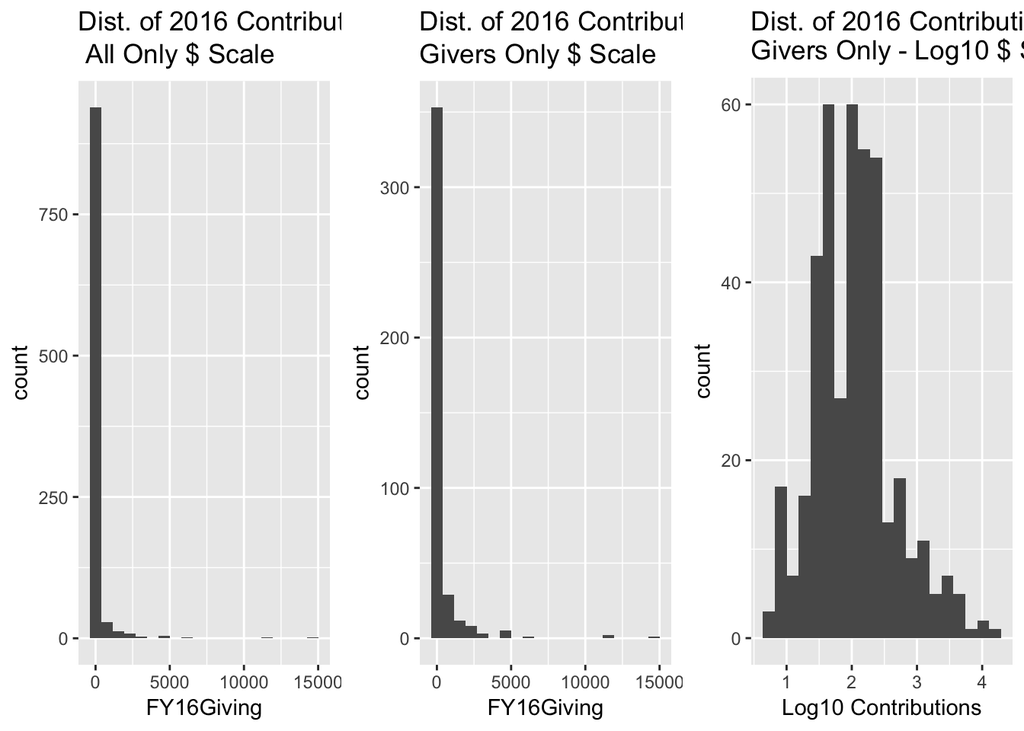

```r
grid.arrange(h1, h2, h3, ncol = 3)
```

Most of the alumni contributed $0; so we see a big spike at 0 and then it tapers off quickly. When we filter for alumni who donated more than 0, we again see a very similar pattern-most alumni who did contribute contributed very little. The distribution is still very skewed;a log-transform might help us see the distribution better.

# Where’s the rest of the univariate analysis? - Is there much else to do? All the rest are category or binary variables, and are described clearly bt the “describe” function

## 2.2.2 Bivariate Analysis:

### Giving in 2016 vs. 2015:

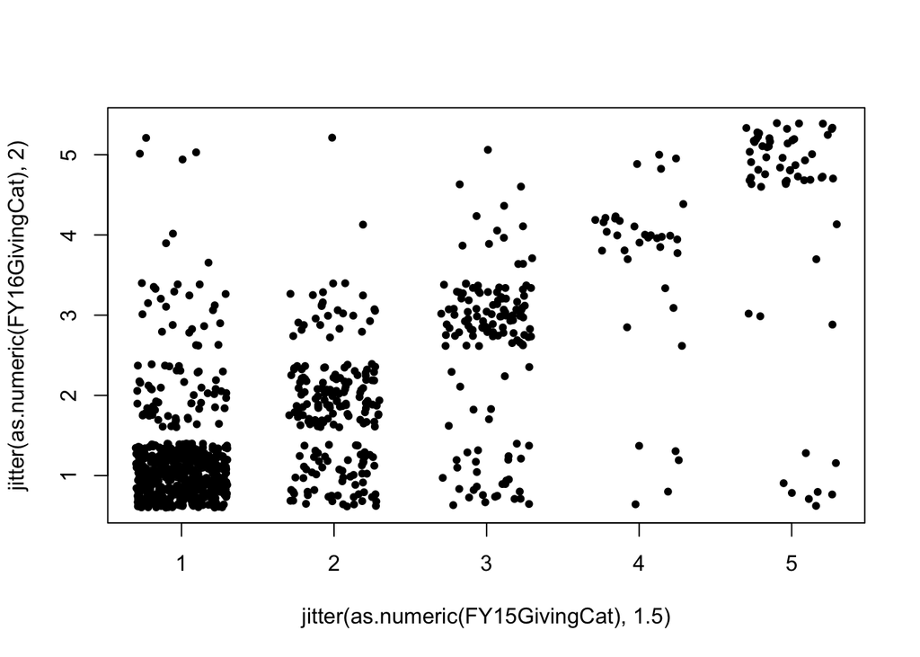

```r
plot(jitter(as.numeric(FY16GivingCat), 2) ~ jitter(as.numeric(FY15GivingCat),
    1.5), data = dt, pch = 20)
```

```r
# Generic function to perform xtab on two variables and
# conduct LRT test of independence.

# Let's comment on assocstats

GenXtab = function(dframe, x1, x2, nlist) {
    x1vsx2 = xtabs(formula = ~x1 + x2, data = dframe)
    names(dimnames(x1vsx2)) = nlist
    print(x1vsx2)
    print("Percentage of Column Totals Shown Below")
    print(round(prop.table(x1vsx2, 2), 2))
    a.s = assocstats(x1vsx2)
    a.s
    if (is.null(a.s$phi) | is.na(a.s$phi)) {
        print("Phi: Not Applicable")
    } else if (abs(a.s$phi) > 0.5) {
        print("Phi: Large Effect")
    } else if (abs(a.s$phi) > 0.3) {
        print("Phi: Medium Effect")
    } else if (abs(a.s$phi) > 0.1) {
        print("Phi: Small Effect")
    } else {
        print("Phi: Negligible Effect")
    }

    if (is.null(a.s$contingency)) {
        print("Contingency Coef: Not Applicable")
    } else if (abs(a.s$contingency) > 0.5) {
        print("Contingency Coef: Large Effect")
    } else if (abs(a.s$contingency) > 0.3) {
        print("Contingency Coef: Medium Effect")
    } else if (abs(a.s$contingency) > 0.1) {
        print("Contingency Coef: Small Effect")
    } else {
        print("Contingency Coef: Negligible Effect")
    }

    if (is.null(a.s$cramer)) {
        print("Cramer's V: Not Applicable")
    } else if (abs(a.s$cramer) > 0.5) {
        print("Cramer's V: Large Effect")
    } else if (abs(a.s$cramer) > 0.3) {
        print("Cramer's V: Medium Effect")
    } else if (abs(a.s$cramer) > 0.1) {
        print("Cramer's V: Small Effect")
    } else {
        print("Cramer's V: Negligible Effect")
    }

}

GenXtab(dt, dt$Giver16, dt$Giver15, c("FY16", "FY15"))
```

```
##     FY15
## FY16   0   1
##    0 480 106
##    1  87 327
## [1] "Percentage of Column Totals Shown Below"
##     FY15
## FY16    0    1
##    0 0.85 0.24
##    1 0.15 0.76
## [1] "Phi: Large Effect"
## [1] "Contingency Coef: Large Effect"
## [1] "Cramer's V: Large Effect"
```

```r
GenXtab(dt, dt$FY16GivingCat, dt$FY15GivingCat, c("FY16", "FY15"))
```

```
##              FY15
## FY16          [0,1) [1,100) [100,250) [250,500) [500,2e+05)
##   [0,1)         480      64        29         5           8
##   [1,100)        57     108         8         0           0
##   [100,250)      23      25        88         4           3
##   [250,500)       3       1        10        23           2
##   [500,2e+05)     4       1         3         4          47
## [1] "Percentage of Column Totals Shown Below"
##              FY15
## FY16          [0,1) [1,100) [100,250) [250,500) [500,2e+05)
##   [0,1)        0.85    0.32      0.21      0.14        0.13
##   [1,100)      0.10    0.54      0.06      0.00        0.00
##   [100,250)    0.04    0.13      0.64      0.11        0.05
##   [250,500)    0.01    0.01      0.07      0.64        0.03
##   [500,2e+05)  0.01    0.01      0.02      0.11        0.78
## [1] "Phi: Not Applicable"
## [1] "Contingency Coef: Large Effect"
## [1] "Cramer's V: Large Effect"
```

```r
GenXtab(dt, dt$Giver16, dt$Giver14, c("FY16", "FY14"))
```

```
##     FY14
## FY16   0   1
##    0 461 125
##    1  92 322
## [1] "Percentage of Column Totals Shown Below"
##     FY14
## FY16    0    1
##    0 0.83 0.28
##    1 0.17 0.72
## [1] "Phi: Large Effect"
## [1] "Contingency Coef: Medium Effect"
## [1] "Cramer's V: Large Effect"
```

```r
GenXtab(dt, dt$FY16GivingCat, dt$FY14GivingCat, c("FY16", "FY14"))
```

```
##              FY14
## FY16          [0,1) [1,100) [100,250) [250,500) [500,2e+05)
##   [0,1)         461      82        34         4           5
##   [1,100)        56     108         8         1           0
##   [100,250)      23      33        74         8           5
##   [250,500)       5       2        15        17           0
##   [500,2e+05)     8       1         5         6          39
## [1] "Percentage of Column Totals Shown Below"
##              FY14
## FY16          [0,1) [1,100) [100,250) [250,500) [500,2e+05)
##   [0,1)        0.83    0.36      0.25      0.11        0.10
##   [1,100)      0.10    0.48      0.06      0.03        0.00
##   [100,250)    0.04    0.15      0.54      0.22        0.10
##   [250,500)    0.01    0.01      0.11      0.47        0.00
##   [500,2e+05)  0.01    0.00      0.04      0.17        0.80
## [1] "Phi: Not Applicable"
## [1] "Contingency Coef: Large Effect"
## [1] "Cramer's V: Large Effect"
```

```r
GenXtab(dt, dt$Giver16, dt$Giver13, c("FY16", "FY13"))
```

```
##     FY13
## FY16   0   1
##    0 441 145
##    1  72 342
## [1] "Percentage of Column Totals Shown Below"
##     FY13
## FY16    0    1
##    0 0.86 0.30
##    1 0.14 0.70
## [1] "Phi: Large Effect"
## [1] "Contingency Coef: Medium Effect"
## [1] "Cramer's V: Large Effect"
```

```r
GenXtab(dt, dt$FY16GivingCat, dt$FY13GivingCat, c("FY16", "FY13"))
```

```
##              FY13
## FY16          [0,1) [1,100) [100,250) [250,500) [500,2e+05)
##   [0,1)         441      94        40         7           4
##   [1,100)        39     123        10         1           0
##   [100,250)      19      27        73        19           5
##   [250,500)       5       0        13        18           3
##   [500,2e+05)     9       3         7         9          31
## [1] "Percentage of Column Totals Shown Below"
##              FY13
## FY16          [0,1) [1,100) [100,250) [250,500) [500,2e+05)
##   [0,1)        0.86    0.38      0.28      0.13        0.09
##   [1,100)      0.08    0.50      0.07      0.02        0.00
##   [100,250)    0.04    0.11      0.51      0.35        0.12
##   [250,500)    0.01    0.00      0.09      0.33        0.07
##   [500,2e+05)  0.02    0.01      0.05      0.17        0.72
## [1] "Phi: Not Applicable"
## [1] "Contingency Coef: Large Effect"
## [1] "Cramer's V: Large Effect"
```

```r
GenXtab(dt, dt$Giver16, dt$Giver12, c("FY16", "FY12"))
```

```
##     FY12
## FY16   0   1
##    0 462 124
##    1  96 318
## [1] "Percentage of Column Totals Shown Below"
##     FY12
## FY16    0    1
##    0 0.83 0.28
##    1 0.17 0.72
## [1] "Phi: Large Effect"
## [1] "Contingency Coef: Medium Effect"
## [1] "Cramer's V: Large Effect"
```

```r
GenXtab(dt, dt$FY16GivingCat, dt$FY12GivingCat, c("FY16", "FY12"))
```

```
##              FY12
## FY16          [0,1) [1,100) [100,250) [250,500) [500,2e+05)
##   [0,1)         462      73        38         9           4
##   [1,100)        60      96        16         0           1
##   [100,250)      26      40        69         5           3
##   [250,500)       4       2        16        16           1
##   [500,2e+05)     6       2        10         7          34
## [1] "Percentage of Column Totals Shown Below"
##              FY12
## FY16          [0,1) [1,100) [100,250) [250,500) [500,2e+05)
##   [0,1)        0.83    0.34      0.26      0.24        0.09
##   [1,100)      0.11    0.45      0.11      0.00        0.02
##   [100,250)    0.05    0.19      0.46      0.14        0.07
##   [250,500)    0.01    0.01      0.11      0.43        0.02
##   [500,2e+05)  0.01    0.01      0.07      0.19        0.79
## [1] "Phi: Not Applicable"
## [1] "Contingency Coef: Large Effect"
## [1] "Cramer's V: Large Effect"
```

```r
GenXtab(dt, dt$Giver16, dt$YearsGiven, c("FY16", "YearsGiven"))
```

```
##     YearsGiven
## FY16   0   1   2   3   4
##    0 343  94  68  54  27
##    1  21  26  56  73 238
## [1] "Percentage of Column Totals Shown Below"
##     YearsGiven
## FY16    0    1    2    3    4
##    0 0.94 0.78 0.55 0.43 0.10
##    1 0.06 0.22 0.45 0.57 0.90
## [1] "Phi: Not Applicable"
## [1] "Contingency Coef: Large Effect"
## [1] "Cramer's V: Large Effect"
```

```r
GenXtab(dt, dt$FY16GivingCat, dt$YearsGiven, c("FY16", "YearsGiven"))
```

```
##              YearsGiven
## FY16            0   1   2   3   4
##   [0,1)       343  94  68  54  27
##   [1,100)      15  15  36  35  72
##   [100,250)     4   7  14  26  92
##   [250,500)     1   1   2   6  29
##   [500,2e+05)   1   3   4   6  45
## [1] "Percentage of Column Totals Shown Below"
##              YearsGiven
## FY16             0    1    2    3    4
##   [0,1)       0.94 0.78 0.55 0.43 0.10
##   [1,100)     0.04 0.12 0.29 0.28 0.27
##   [100,250)   0.01 0.06 0.11 0.20 0.35
##   [250,500)   0.00 0.01 0.02 0.05 0.11
##   [500,2e+05) 0.00 0.02 0.03 0.05 0.17
## [1] "Phi: Not Applicable"
## [1] "Contingency Coef: Large Effect"
## [1] "Cramer's V: Medium Effect"
```

```r
GenXtab(dt, dt$Giver16, dt$MajorCat, c("FY16", "MajorCat"))
```

```
##     MajorCat
## FY16 HUM_ART OTHER SOCIAL_SCIENCE STEM
##    0     272    37            156  121
##    1     179    38            104   93
## [1] "Percentage of Column Totals Shown Below"
##     MajorCat
## FY16 HUM_ART OTHER SOCIAL_SCIENCE STEM
##    0    0.60  0.49           0.60 0.57
##    1    0.40  0.51           0.40 0.43
## [1] "Phi: Not Applicable"
## [1] "Contingency Coef: Negligible Effect"
## [1] "Cramer's V: Negligible Effect"
```

```r
GenXtab(dt, dt$FY16GivingCat, dt$MajorCat, c("FY16", "MajorCat"))
```

```
##              MajorCat
## FY16          HUM_ART OTHER SOCIAL_SCIENCE STEM
##   [0,1)           272    37            156  121
##   [1,100)          72    14             46   41
##   [100,250)        65    14             32   32
##   [250,500)        19     2             10    8
##   [500,2e+05)      23     8             16   12
## [1] "Percentage of Column Totals Shown Below"
##              MajorCat
## FY16          HUM_ART OTHER SOCIAL_SCIENCE STEM
##   [0,1)          0.60  0.49           0.60 0.57
##   [1,100)        0.16  0.19           0.18 0.19
##   [100,250)      0.14  0.19           0.12 0.15
##   [250,500)      0.04  0.03           0.04 0.04
##   [500,2e+05)    0.05  0.11           0.06 0.06
## [1] "Phi: Not Applicable"
## [1] "Contingency Coef: Negligible Effect"
## [1] "Cramer's V: Negligible Effect"
```

```r
GenXtab(dt, dt$Giver16, dt$NextDegCat, c("FY16", "NextDegCat"))
```

```
##     NextDegCat
## FY16   0   1
##    0 272 314
##    1 106 308
## [1] "Percentage of Column Totals Shown Below"
##     NextDegCat
## FY16    0    1
##    0 0.72 0.50
##    1 0.28 0.50
## [1] "Phi: Small Effect"
## [1] "Contingency Coef: Small Effect"
## [1] "Cramer's V: Small Effect"
```

```r
GenXtab(dt, dt$FY16GivingCat, dt$NextDegCat, c("FY16", "NextDegCat"))
```

```
##              NextDegCat
## FY16            0   1
##   [0,1)       272 314
##   [1,100)      41 132
##   [100,250)    41 102
##   [250,500)    15  24
##   [500,2e+05)   9  50
## [1] "Percentage of Column Totals Shown Below"
##              NextDegCat
## FY16             0    1
##   [0,1)       0.72 0.50
##   [1,100)     0.11 0.21
##   [100,250)   0.11 0.16
##   [250,500)   0.04 0.04
##   [500,2e+05) 0.02 0.08
## [1] "Phi: Not Applicable"
## [1] "Contingency Coef: Small Effect"
## [1] "Cramer's V: Small Effect"
```

> *Do the xtabs take up too much space?*

### Giving in 2016 vs. Alumni Event Attendance:

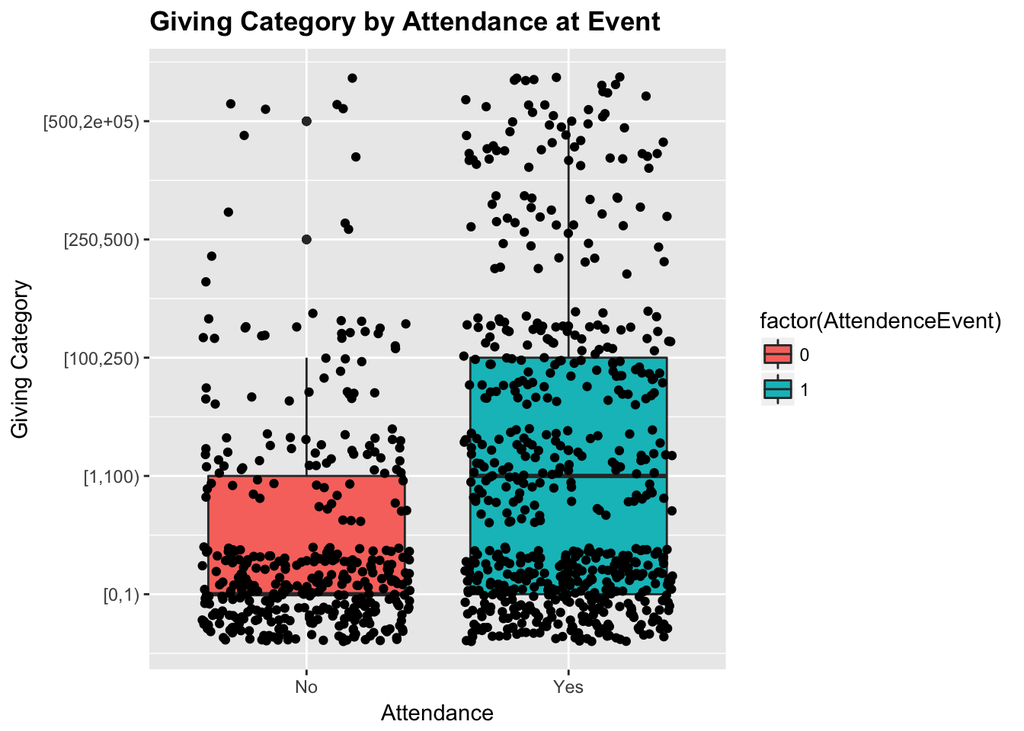

```r
ggplot(dt, aes(factor(AttendenceEvent), as.numeric(FY16GivingCat))) +
    geom_boxplot(aes(fill = factor(AttendenceEvent))) + ggtitle("Giving Category by Attendance at Event") +
    geom_jitter() + scale_x_discrete(name = "Attendance", labels = c("No",
    "Yes")) + scale_y_continuous(name = "Giving Category", breaks = 1:5,
    labels = c("[0,1)", "[1,100)", "[100,250)", "[250,500)",
        "[500,2e+05)")) + theme(plot.title = element_text(lineheight = 1,
    face = "bold"))
```

```r
GenXtab(dt, dt$Giver16, dt$AttendenceEvent, c("FY16", "Attendance"))
```

```
##     Attendance
## FY16   0   1
##    0 286 300
##    1 109 305
## [1] "Percentage of Column Totals Shown Below"
##     Attendance
## FY16    0    1
##    0 0.72 0.50
##    1 0.28 0.50
## [1] "Phi: Small Effect"
## [1] "Contingency Coef: Small Effect"
## [1] "Cramer's V: Small Effect"
```

```r
GenXtab(dt, dt$FY16GivingCat, dt$AttendenceEvent, c("FY16", "Attendance"))
```

```
##              Attendance
## FY16            0   1
##   [0,1)       286 300
##   [1,100)      61 112
##   [100,250)    36 107
##   [250,500)     5  34
##   [500,2e+05)   7  52
## [1] "Percentage of Column Totals Shown Below"
##              Attendance
## FY16             0    1
##   [0,1)       0.72 0.50
##   [1,100)     0.15 0.19
##   [100,250)   0.09 0.18
##   [250,500)   0.01 0.06
##   [500,2e+05) 0.02 0.09
## [1] "Phi: Not Applicable"
## [1] "Contingency Coef: Small Effect"
## [1] "Cramer's V: Small Effect"
```

So there does seem to be a relationship between attendence at alumni events in 2012-2015 and 2016 giving. 50% of those attending gave in 2016 while only 28% of those not attending gave in 2016.

### Giving in 2016 by Marital status:

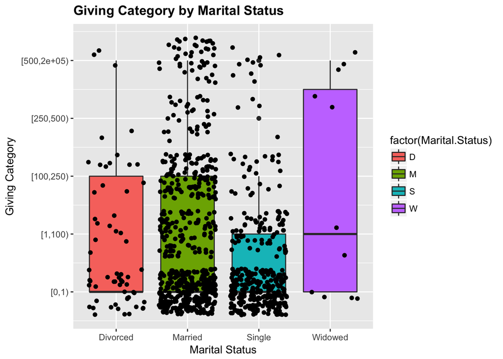

```r
ggplot(dt, aes(factor(Marital.Status), as.numeric(FY16GivingCat))) +
    geom_boxplot(aes(fill = factor(Marital.Status))) + ggtitle("Giving Category by Marital Status") +
    geom_jitter() + scale_x_discrete(name = "Marital Status",
    labels = c("Divorced", "Married", "Single", "Widowed")) +
    scale_y_continuous(name = "Giving Category", breaks = 1:5,
        labels = c("[0,1)", "[1,100)", "[100,250)", "[250,500)",
            "[500,2e+05)")) + theme(plot.title = element_text(lineheight = 1,
    face = "bold"))
```

```r
GenXtab(dt, dt$Giver16, dt$Marital.Status, c("FY16", "Marital Status"))
```

```
##     Marital Status
## FY16   D   M   S   W
##    0  36 305 241   4
##    1  25 279 103   7
## [1] "Percentage of Column Totals Shown Below"
##     Marital Status
## FY16    D    M    S    W
##    0 0.59 0.52 0.70 0.36
##    1 0.41 0.48 0.30 0.64
## [1] "Phi: Not Applicable"
## [1] "Contingency Coef: Small Effect"
## [1] "Cramer's V: Small Effect"
```

```r
GenXtab(dt, dt$FY16GivingCat, dt$Marital.Status, c("FY16", "Marital Status"))
```

```
##              Marital Status
## FY16            D   M   S   W
##   [0,1)        36 305 241   4
##   [1,100)       9  96  66   2
##   [100,250)    11 109  23   0
##   [250,500)     2  31   4   2
##   [500,2e+05)   3  43  10   3
## [1] "Percentage of Column Totals Shown Below"
##              Marital Status
## FY16             D    M    S    W
##   [0,1)       0.59 0.52 0.70 0.36
##   [1,100)     0.15 0.16 0.19 0.18
##   [100,250)   0.18 0.19 0.07 0.00
##   [250,500)   0.03 0.05 0.01 0.18
##   [500,2e+05) 0.05 0.07 0.03 0.27
## [1] "Phi: Not Applicable"
## [1] "Contingency Coef: Small Effect"
## [1] "Cramer's V: Small Effect"
```

Most of the Alumni fall into either Married or Single category and Married Alumni are more likely to give than Single.  
There are very few data points for Widowed and Divorced alumni - so we do not want to make broad conclusions, but it appears that there are both Divorced and Widowed Alumni that contribute high amounts (and there are those that contribute nothing too in these categories) One possible reason we are seeing Married giving more than Single might actually have to do with age. Older Alumni are more likely to be married and older alumni are also probably a bit more well established financially - so more likely to contribute to charitable causes. So Marital status vs. Giving might simply be capturing the relationship between Age and Giving. While age is not a variable that’s available in the dataset, we have “Class Year” which is a good proxy for age.

### Giving 2016 vs. Class Year:

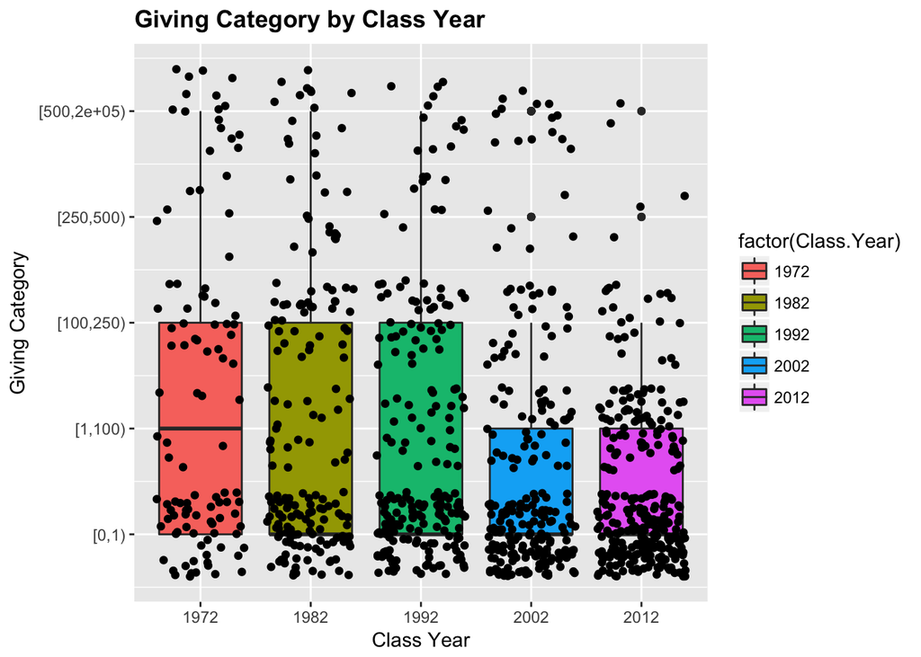

```r
ggplot(dt, aes(factor(Class.Year), as.numeric(FY16GivingCat))) +
    geom_boxplot(aes(fill = factor(Class.Year))) + ggtitle("Giving Category by Class Year") +
    geom_jitter() + scale_x_discrete(name = "Class Year") + scale_y_continuous(name = "Giving Category",
    breaks = 1:5, labels = c("[0,1)", "[1,100)", "[100,250)",
        "[250,500)", "[500,2e+05)")) + theme(plot.title = element_text(lineheight = 1,
    face = "bold"))
```

```r
GenXtab(dt, dt$Giver16, dt$Class.Year, c("FY16", "Class"))
```

```
##     Class
## FY16 1972 1982 1992 2002 2012
##    0   50   90  115  137  194
##    1   55   86   88   86   99
## [1] "Percentage of Column Totals Shown Below"
##     Class
## FY16 1972 1982 1992 2002 2012
##    0 0.48 0.51 0.57 0.61 0.66
##    1 0.52 0.49 0.43 0.39 0.34
## [1] "Phi: Not Applicable"
## [1] "Contingency Coef: Small Effect"
## [1] "Cramer's V: Small Effect"
```

```r
GenXtab(dt, dt$FY16GivingCat, dt$Class.Year, c("FY16", "Class"))
```

```
##              Class
## FY16          1972 1982 1992 2002 2012
##   [0,1)         50   90  115  137  194
##   [1,100)        9   22   29   41   72
##   [100,250)     23   35   38   25   22
##   [250,500)      7   14    9    6    3
##   [500,2e+05)   16   15   12   14    2
## [1] "Percentage of Column Totals Shown Below"
##              Class
## FY16          1972 1982 1992 2002 2012
##   [0,1)       0.48 0.51 0.57 0.61 0.66
##   [1,100)     0.09 0.12 0.14 0.18 0.25
##   [100,250)   0.22 0.20 0.19 0.11 0.08
##   [250,500)   0.07 0.08 0.04 0.03 0.01
##   [500,2e+05) 0.15 0.09 0.06 0.06 0.01
## [1] "Phi: Not Applicable"
## [1] "Contingency Coef: Small Effect"
## [1] "Cramer's V: Small Effect"
```

Here, it indeed looks like the older the alumnus, the more likely he or she is to give money.

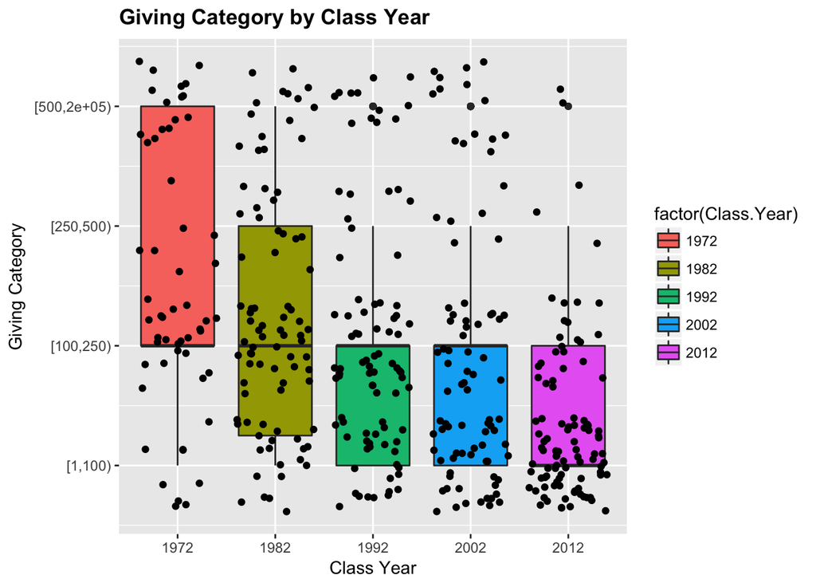

```r
ggplot(dt[dt$FY16Giving > 0, ], aes(factor(Class.Year), as.numeric(FY16GivingCat))) +
    geom_boxplot(aes(fill = factor(Class.Year))) + ggtitle("Giving Category by Class Year") +
    geom_jitter() + scale_x_discrete(name = "Class Year") + scale_y_continuous(name = "Giving Category",
    breaks = 1:5, labels = c("[0,1)", "[1,100)", "[100,250)",
        "[250,500)", "[500,2e+05)")) + theme(plot.title = element_text(lineheight = 1,
    face = "bold"))
```

### Giving in 2016 by Gender:

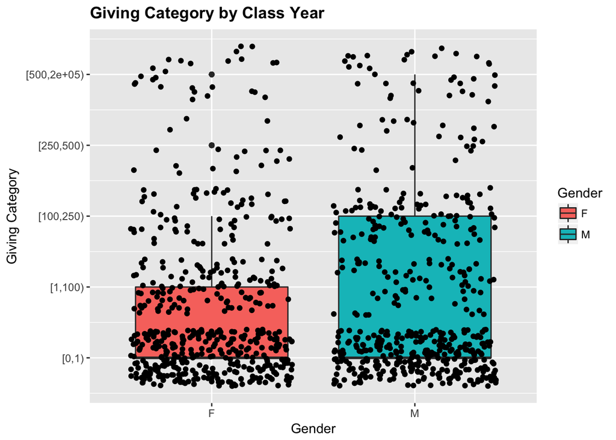

```r
ggplot(dt, aes(Gender, as.numeric(FY16GivingCat))) + geom_boxplot(aes(fill = Gender)) +
    ggtitle("Giving Category by Class Year") + geom_jitter() +
    scale_x_discrete(name = "Gender") + scale_y_continuous(name = "Giving Category",
    breaks = 1:5, labels = c("[0,1)", "[1,100)", "[100,250)",
        "[250,500)", "[500,2e+05)")) + theme(plot.title = element_text(lineheight = 1,
    face = "bold"))
```

```r
GenXtab(dt, dt$Giver16, dt$Gender, c("Giver16", "Gender"))
```

```
##        Gender
## Giver16   F   M
##       0 298 288
##       1 207 207
## [1] "Percentage of Column Totals Shown Below"
##        Gender
## Giver16    F    M
##       0 0.59 0.58
##       1 0.41 0.42
## [1] "Phi: Negligible Effect"
## [1] "Contingency Coef: Negligible Effect"
## [1] "Cramer's V: Negligible Effect"
```

```r
GenXtab(dt, dt$FY16GivingCat, dt$Gender, c("FY16", "Gender"))
```

```
##              Gender
## FY16            F   M
##   [0,1)       298 288
##   [1,100)     106  67
##   [100,250)    58  85
##   [250,500)    17  22
##   [500,2e+05)  26  33
## [1] "Percentage of Column Totals Shown Below"
##              Gender
## FY16             F    M
##   [0,1)       0.59 0.58
##   [1,100)     0.21 0.14
##   [100,250)   0.11 0.17
##   [250,500)   0.03 0.04
##   [500,2e+05) 0.05 0.07
## [1] "Phi: Not Applicable"
## [1] "Contingency Coef: Small Effect"
## [1] "Cramer's V: Small Effect"
```

There is no statistical evidence that whether or not Alumni Give in 2016 varies by Gender (41% of Females Gave vs. 42% of Males). However when we look at the categories of contribution in 2016 by Gender, we see differences worth investigating later. There may be other factors at play here, for e.g. we know that older alumni tend to give more than younger alumni; it is possible that there are fewer “older” female alumni (fewer women attended college in 1972) than Male. > *AY Note: Not sure we should be rejecting hypothesis in the EDA stage*

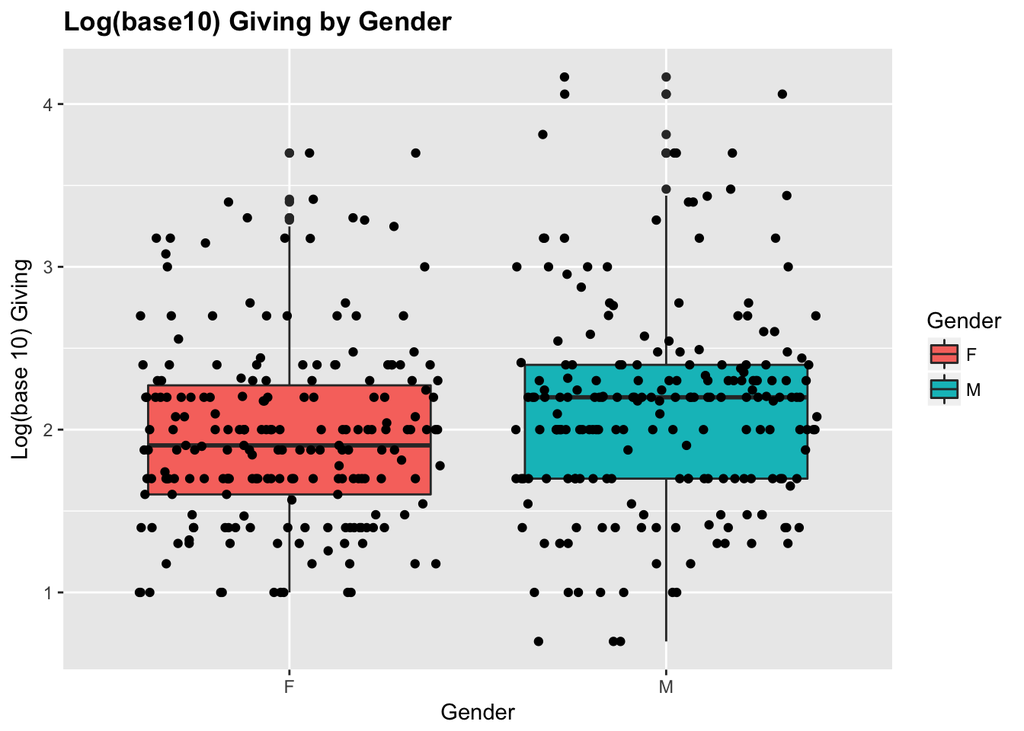

```r
ggplot(dt[FY16Giving > 0], aes(Gender, log10(FY16Giving))) +
    geom_boxplot(aes(fill = Gender)) + ggtitle("Log(base10) Giving by Gender") +
    geom_jitter() + scale_x_discrete(name = "Gender") + scale_y_continuous(name = "Log(base 10) Giving") +
    theme(plot.title = element_text(lineheight = 1, face = "bold"))
```

Of those that donate, men donate more. But we can’t be sure this is significant as the median man donated less than the 75th percentile woman.

Is there a relationship between Gender and Class Year i.e. do we see a higher proportion of “Men” in the sample as age goes up (proxy for age is Class Year)?

```r
GenXtab(dt, dt$Gender, dt$Class.Year, c("Gender", "ClassYear"))
```

```
##       ClassYear
## Gender 1972 1982 1992 2002 2012
##      F   38   80  102  133  152
##      M   67   96  101   90  141
## [1] "Percentage of Column Totals Shown Below"
##       ClassYear
## Gender 1972 1982 1992 2002 2012
##      F 0.36 0.45 0.50 0.60 0.52
##      M 0.64 0.55 0.50 0.40 0.48
## [1] "Phi: Not Applicable"
## [1] "Contingency Coef: Small Effect"
## [1] "Cramer's V: Small Effect"
```

So let’s look at Contribution by class year split by male and female:

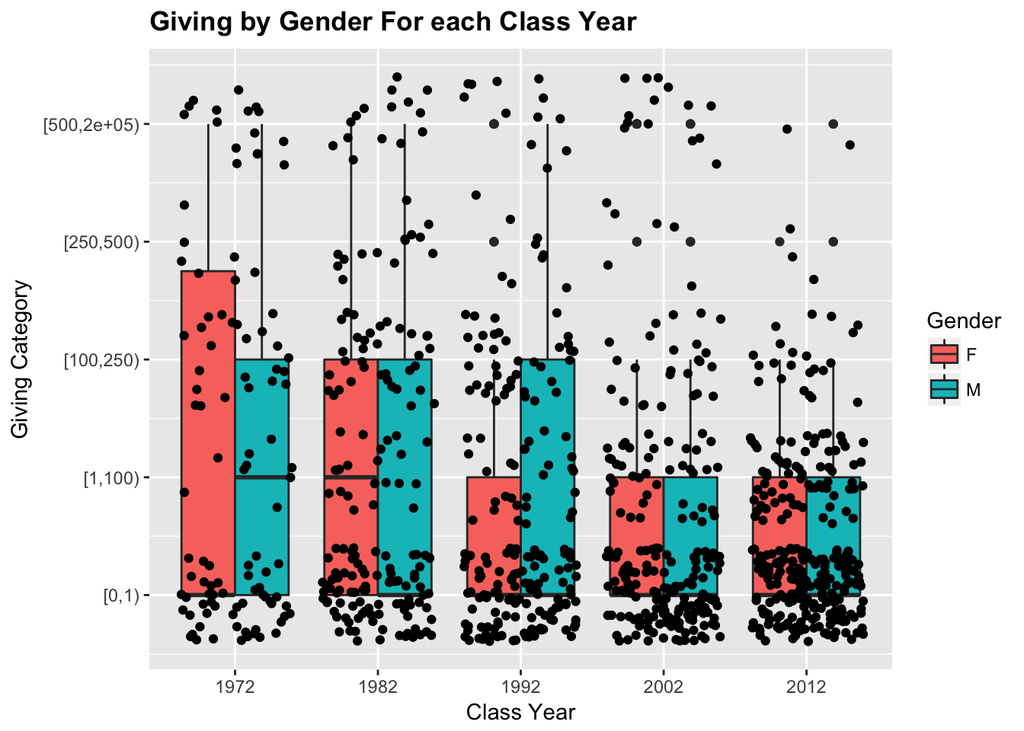

```r
ggplot(dt, aes(factor(Class.Year), as.numeric(FY16GivingCat))) +
    geom_boxplot(aes(fill = Gender)) + ggtitle("Giving by Gender For each Class Year") +
    geom_jitter() + scale_x_discrete(name = "Class Year") + scale_y_continuous(name = "Giving Category",
    breaks = 1:5, labels = c("[0,1)", "[1,100)", "[100,250)",
        "[250,500)", "[500,2e+05)")) + theme(plot.title = element_text(lineheight = 1,
    face = "bold"))
```

So split by class year, gender does not seem to be a significant factor, and in fact older women donate more than older men

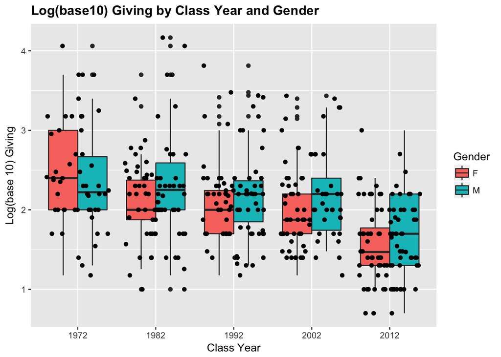

```r
ggplot(dt[FY16Giving > 0], aes(factor(Class.Year), log10(FY16Giving))) +
    geom_boxplot(aes(fill = Gender)) + ggtitle("Log(base10) Giving by Class Year and Gender") +
    geom_jitter() + scale_x_discrete(name = "Class Year") + scale_y_continuous(name = "Log(base 10) Giving") +
    theme(plot.title = element_text(lineheight = 1, face = "bold"))
```

SO limiting it to just alumni who donated in 2016, we do see that even split by age, men donated more than women, except for the oldest alumni